# Bootstrapping Bombyx Repeats: Round1

Author

James R. Walters

Published

October 22, 2026

# 1 Overview

This represents a first-draft attempt to implement bootstrapping analyses and associated visualizations implemented to address reviewer concerns regarding the lack of confidence intervals on prominent observations regarding repeat content, richness, and similarity between B. mori and B. mandarina.

Most of the code for implementing this bootstrapping has been developed in the context of a package, developed specifically for this purpose:

https://github.com/WaltersLab/BootstrapBombyxRepeats

This script employs the functions and methods developed in that package to add bootstrapped-derived estimates of uncertainty for these point estimates.

# 2 Libraries

```r
library(BootstrapBombyxRepeats)
library(kableExtra)
library(ggplot2)
library(cowplot)
library(patchwork)
```

# 3 Import Data

Due to the long run-time to resolve the repeat overlaps, I ran that step on the cluster. So these upstream steps are in shell sbatch scripts.

```r
inputPath <- "/Users/j036w617/Documents/Projects/Bombyx_W_comparisons/Bombyx_W_analyses/bootstrapping/round1/"
```

## 3.1 Import resolved repeats

Both data files are saved as objects called `bmResolved`, so I’ll need to rename them. And remove the object to avoid confusion

```r
load(file = "Bmand_Repeats_Resolved.Rda")
BmandReps <- bmResolved

load(file = "Bmori_Repeats_Resolved.Rda")
BmoriReps <- bmResolved

rm(bmResolved)
```

## 3.2 Import other data

### 3.2.1 Import B. mori

```r
moriChroms <- read.delim(file = "Bmori_ChrAccLen.tsv")

# create a look-up vector with `Chr` values and Accession names
moriLookupVec <- setNames(nm = moriChroms$contig ,
                      object = paste0("Chr",moriChroms$chromosome) )

# Also create a chrom-lengths vector for use with functions
moriChrLengths <- setNames(object = moriChroms$length ,
                         nm = paste0("Chr",moriChroms$chromosome) )
```

### 3.2.2 Import B. mandarina

```r
mandChroms <- read.delim(file =  "Bmand_ChrAccLen.tsv")


# create a look-up vector with `Chr` values and Accession names
mandLookupVec <- setNames(nm = mandChroms$contig ,
                      object = paste0("Chr",mandChroms$chromosome) )

# Also create a chrom-lengths vector for use with functions
mandChrLengths <- setNames(object = mandChroms$length ,
                         nm = paste0("Chr",mandChroms$chromosome) )
```

## 3.3 Import Repeat Type

```r
repType <- read.delim(file = "repeat_classes.tsv",
                      col.names = c("repeat_family", "repeat_class", "subclass"))

# parsing of the library fasta resulted in some extra white-spaces.
repType$repeat_family <- trimws(repType$repeat_family)
repType$repeat_class <- trimws(repType$repeat_class)
repType$subclass <- trimws(repType$subclass)
repType$repeat_class[repType$repeat_class == "PLE"] <- "Penelope"
repType$repeat_class[repType$repeat_class == "RC"] <- "Helitron"
table(repType$repeat_class)
```

```
      DNA  Helitron      LINE       LTR  Penelope Satellite      SINE     snRNA
      173        83       378       202         4        16        32         4
     tRNA   Unknown
        3       890
```

```r
nrow(repType)
```

```
[1] 1785
```

### 3.3.1 Parsing repeat type

I think Martina updated the naming scheme of the library after repeat masking. So to map repeat family to type (class), I need to replace the “origin” prefix.

```r
fixRep <- repType$repeat_family
fixRep <- sub(pattern = "p50ma" , replacement ="GCF" , x = fixRep)
fixRep <- sub(pattern = "p50T" , replacement ="GCA" , x = fixRep)
fixRep <- sub(pattern = "Sakado" , replacement ="mandarina" , x = fixRep)
fixRep <- sub(pattern = "Dazao_" , replacement ="" , x = fixRep)

repType$repeat_family <- fixRep

# head(sort(table(fixRep), decreasing = T ))
```

# 4 Summarize Resolutions

## 4.1 B. mori resolutions

```r
moriResolvedSummary <- S4Vectors::metadata(BmoriReps)
moriResolvedSummary$overlap_resolution
```

```
$input_annotations
[1] 1108164

$retained_annotations
[1] 1061633

$removed_annotations
[1] 46531

$output_fragments
[1] 1063127

$raw_annotation_bp
[1] 266131490

$unique_repeat_bp
[1] 232831772

$redundant_overlap_bp
[1] 33299718

$resolved_bp
[1] 232831772

$input_families
[1] 1771

$retained_families
[1] 1770

$removed_families
[1] 1
```

```r
kbl(moriResolvedSummary$overlap_resolution_by_chromosome) |>
  kable_styling(bootstrap_options = c("striped", "hover", "condensed"),
                font_size = 9, fixed_thead = T) |>
  scroll_box(width = "100%", height = "400px")
```

| chromosome | input_annotations | retained_annotations | removed_annotations | output_fragments | raw_annotation_bp | unique_repeat_bp | redundant_overlap_bp | resolved_bp | input_families | retained_families | removed_families |
| --- | --- | --- | --- | --- | --- | --- | --- | --- | --- | --- | --- |
| Chr1 | 40116 | 38592 | 1524 | 38655 | 9515786 | 8366131 | 1149655 | 8366131 | 1457 | 1454 | 3 |
| Chr10 | 38139 | 36688 | 1451 | 36741 | 8903717 | 7764865 | 1138852 | 7764865 | 1426 | 1422 | 4 |
| Chr11 | 50956 | 48787 | 2169 | 48849 | 11609203 | 10136836 | 1472367 | 10136836 | 1533 | 1530 | 3 |
| Chr12 | 40863 | 39188 | 1675 | 39255 | 10110829 | 8859573 | 1251256 | 8859573 | 1456 | 1454 | 2 |
| Chr13 | 40019 | 38455 | 1564 | 38519 | 9584113 | 8348867 | 1235246 | 8348867 | 1431 | 1427 | 4 |
| Chr14 | 35825 | 34368 | 1457 | 34416 | 8234919 | 7179602 | 1055317 | 7179602 | 1471 | 1469 | 2 |
| Chr15 | 42399 | 40747 | 1652 | 40798 | 10006382 | 8766285 | 1240097 | 8766285 | 1480 | 1478 | 2 |
| Chr16 | 38351 | 36779 | 1572 | 36833 | 8960111 | 7810277 | 1149834 | 7810277 | 1467 | 1464 | 3 |
| Chr17 | 41101 | 39390 | 1711 | 39448 | 9823804 | 8583210 | 1240594 | 8583210 | 1463 | 1459 | 4 |
| Chr18 | 38572 | 36981 | 1591 | 37045 | 8970108 | 7781142 | 1188966 | 7781142 | 1403 | 1399 | 4 |
| Chr19 | 37144 | 35618 | 1526 | 35670 | 8855481 | 7722744 | 1132737 | 7722744 | 1434 | 1428 | 6 |
| Chr2 | 27612 | 26207 | 1405 | 26242 | 5981293 | 5142711 | 838582 | 5142711 | 1270 | 1267 | 3 |
| Chr20 | 35865 | 34226 | 1639 | 34266 | 8394550 | 7338427 | 1056123 | 7338427 | 1478 | 1473 | 5 |
| Chr21 | 37817 | 36279 | 1538 | 36339 | 8970850 | 7841900 | 1128950 | 7841900 | 1425 | 1423 | 2 |
| Chr22 | 41571 | 39870 | 1701 | 39936 | 10165219 | 8881478 | 1283741 | 8881478 | 1442 | 1438 | 4 |
| Chr23 | 54142 | 51916 | 2226 | 51984 | 12229128 | 10639414 | 1589714 | 10639414 | 1503 | 1501 | 2 |
| Chr24 | 54259 | 51472 | 2787 | 51534 | 13212011 | 11601066 | 1610945 | 11601066 | 1557 | 1554 | 3 |
| Chr25 | 36372 | 34900 | 1472 | 34951 | 8264394 | 7149883 | 1114511 | 7149883 | 1401 | 1398 | 3 |
| Chr26 | 33917 | 32343 | 1574 | 32383 | 7481489 | 6464549 | 1016940 | 6464549 | 1370 | 1366 | 4 |
| Chr27 | 30241 | 28991 | 1250 | 29026 | 6587393 | 5716749 | 870644 | 5716749 | 1325 | 1322 | 3 |
| Chr28 | 33194 | 31616 | 1578 | 31662 | 7319904 | 6327680 | 992224 | 6327680 | 1355 | 1353 | 2 |
| Chr3 | 37368 | 35871 | 1497 | 35925 | 8569769 | 7437866 | 1131903 | 7437866 | 1417 | 1417 | 0 |
| Chr4 | 39918 | 38454 | 1464 | 38505 | 9621902 | 8434147 | 1187755 | 8434147 | 1453 | 1452 | 1 |
| Chr5 | 41894 | 40200 | 1694 | 40255 | 9959896 | 8694947 | 1264949 | 8694947 | 1469 | 1465 | 4 |
| Chr6 | 38015 | 36439 | 1576 | 36483 | 9244946 | 8070737 | 1174209 | 8070737 | 1443 | 1436 | 7 |
| Chr7 | 36220 | 34658 | 1562 | 34703 | 8322764 | 7226188 | 1096576 | 7226188 | 1449 | 1444 | 5 |
| Chr8 | 39235 | 37597 | 1638 | 37649 | 9254378 | 8085788 | 1168590 | 8085788 | 1450 | 1446 | 4 |
| Chr9 | 39707 | 38078 | 1629 | 38129 | 9421846 | 8222325 | 1199521 | 8222325 | 1439 | 1432 | 7 |
| ChrW | 7332 | 6923 | 409 | 6926 | 8555305 | 8236385 | 318920 | 8236385 | 685 | 653 | 32 |

## 4.2 B. mandarina resolutions

```r
mandResolvedSummary <- S4Vectors::metadata(BmandReps)
mandResolvedSummary$overlap_resolution
```

```
$input_annotations
[1] 1030595

$retained_annotations
[1] 986777

$removed_annotations
[1] 43818

$output_fragments
[1] 988097

$raw_annotation_bp
[1] 242843292

$unique_repeat_bp
[1] 211893368

$redundant_overlap_bp
[1] 30949924

$resolved_bp
[1] 211893368

$input_families
[1] 1767

$retained_families
[1] 1766

$removed_families
[1] 1
```

```r
kbl(mandResolvedSummary$overlap_resolution_by_chromosome) |>
  kable_styling(bootstrap_options = c("striped", "hover", "condensed"),
                font_size = 9, fixed_thead = T) |>
  scroll_box(width = "100%", height = "400px")
```

| chromosome | input_annotations | retained_annotations | removed_annotations | output_fragments | raw_annotation_bp | unique_repeat_bp | redundant_overlap_bp | resolved_bp | input_families | retained_families | removed_families |
| --- | --- | --- | --- | --- | --- | --- | --- | --- | --- | --- | --- |
| Chr1 | 39548 | 38091 | 1457 | 38129 | 9174499 | 8056781 | 1117718 | 8056781 | 1448 | 1445 | 3 |
| Chr10 | 33163 | 31847 | 1316 | 31890 | 7537982 | 6542297 | 995685 | 6542297 | 1356 | 1349 | 7 |
| Chr11 | 50776 | 48585 | 2191 | 48644 | 11063644 | 9632485 | 1431159 | 9632485 | 1511 | 1510 | 1 |
| Chr12 | 40069 | 38399 | 1670 | 38449 | 9309229 | 8098700 | 1210529 | 8098700 | 1447 | 1443 | 4 |
| Chr13 | 36059 | 34592 | 1467 | 34635 | 8369807 | 7272307 | 1097500 | 7272307 | 1380 | 1378 | 2 |
| Chr15 | 41170 | 39549 | 1621 | 39604 | 9453870 | 8248066 | 1205804 | 8248066 | 1447 | 1442 | 5 |
| Chr16 | 37922 | 36256 | 1666 | 36306 | 8611036 | 7489233 | 1121803 | 7489233 | 1430 | 1425 | 5 |
| Chr17 | 36809 | 35308 | 1501 | 35360 | 8688089 | 7592493 | 1095596 | 7592493 | 1404 | 1402 | 2 |
| Chr18 | 35274 | 33725 | 1549 | 33770 | 7948337 | 6879011 | 1069326 | 6879011 | 1353 | 1351 | 2 |
| Chr19 | 37383 | 35841 | 1542 | 35891 | 8283310 | 7162740 | 1120570 | 7162740 | 1426 | 1419 | 7 |
| Chr2 | 26104 | 24815 | 1289 | 24845 | 5537047 | 4771543 | 765504 | 4771543 | 1271 | 1269 | 2 |
| Chr20 | 34369 | 32739 | 1630 | 32780 | 7788455 | 6783618 | 1004837 | 6783618 | 1450 | 1447 | 3 |
| Chr21 | 36932 | 35378 | 1554 | 35432 | 8317335 | 7207005 | 1110330 | 7207005 | 1406 | 1405 | 1 |
| Chr22 | 41223 | 39578 | 1645 | 39650 | 9819757 | 8567021 | 1252736 | 8567021 | 1440 | 1439 | 1 |
| Chr23 | 51881 | 49751 | 2130 | 49814 | 11575699 | 10071025 | 1504674 | 10071025 | 1477 | 1472 | 5 |
| Chr24 | 33534 | 31789 | 1745 | 31827 | 7960090 | 6970847 | 989243 | 6970847 | 1388 | 1386 | 2 |
| Chr25 | 29409 | 28194 | 1215 | 28236 | 6473371 | 5605125 | 868246 | 5605125 | 1327 | 1324 | 3 |
| Chr26 | 25089 | 23931 | 1158 | 23969 | 5427834 | 4673265 | 754569 | 4673265 | 1238 | 1235 | 3 |
| Chr28 | 33073 | 31489 | 1584 | 31529 | 7203887 | 6188541 | 1015346 | 6188541 | 1342 | 1340 | 2 |
| Chr3 | 37613 | 36006 | 1607 | 36059 | 8521330 | 7390043 | 1131287 | 7390043 | 1432 | 1428 | 4 |
| Chr4 | 37569 | 36070 | 1499 | 36122 | 8623244 | 7496012 | 1127232 | 7496012 | 1419 | 1417 | 2 |
| Chr5 | 39750 | 38227 | 1523 | 38281 | 9369888 | 8168904 | 1200984 | 8168904 | 1424 | 1422 | 2 |
| Chr6 | 33312 | 31837 | 1475 | 31873 | 7635988 | 6609120 | 1026868 | 6609120 | 1385 | 1380 | 5 |
| Chr7 | 32597 | 31226 | 1371 | 31271 | 7270301 | 6277593 | 992708 | 6277593 | 1412 | 1409 | 3 |
| Chr8 | 38587 | 37075 | 1512 | 37130 | 8685744 | 7515729 | 1170015 | 7515729 | 1441 | 1436 | 5 |
| Chr9 | 38500 | 36887 | 1613 | 36929 | 8844724 | 7686462 | 1158262 | 7686462 | 1408 | 1405 | 3 |
| ChrA1 | 64303 | 61613 | 2690 | 61690 | 14045978 | 12157702 | 1888276 | 12157702 | 1586 | 1584 | 2 |
| ChrW | 8577 | 7979 | 598 | 7982 | 11302817 | 10779700 | 523117 | 10779700 | 637 | 605 | 32 |

# 5 Build Block Data

We will build the data structure that breaks the repeat annotations in each segments for each chromosome.

```r
blockSize <- 100000
```

## 5.1 B. mori blocks

```r
moriBlocks <- build_block_data(repeats = BmoriReps,
                             chr_lengths = moriChrLengths,
                             chromosome_map = NULL,
                             assembly = "p50T",
                             target_width = blockSize,
                             family_col = "repeat_family",
                             repeat_classes = repType)
```

## 5.2 B. mandarina blocks

```r
mandBlocks <- build_block_data(repeats = BmandReps,
                             chr_lengths = mandChrLengths,
                             chromosome_map = NULL,
                             assembly = "mandarina",
                             target_width = blockSize,
                             family_col = "repeat_family",
                             repeat_classes = repType)
```

## 5.3 Observed results

From these block structures, we can extract the observed values for the whole genome by chromosome or groupings (e.g. Z, W, A). These results by chromosome are already available inside the result from `build_block_data()`, e.g., `moriBlocks$osberved`. But these functions support correctly aggregating results by groups (e.g. ZWA), and also provide the input for `bootstrap_ci()` function used later to give confidence intervals alongside observed values.

### 5.3.1 For Fractions

#### 5.3.1.1 mori

```r
moriFracObs <- observed_fraction(block_data = moriBlocks)

morizwa <- c("Z", rep("A", 27), "W")
names(morizwa) <- names(moriChrLengths)

moriFracObsZWA <- observed_fraction(block_data = moriBlocks,
                                 chromosome_groups = morizwa)
```

```r
kbl(moriFracObs, caption = "B. mori repeat fraction by chromosome") |>
  kable_styling(bootstrap_options = c("striped", "hover", "condensed"),
                font_size = 9, fixed_thead = T) |>
  scroll_box(width = "100%", height = "400px")
```

B. mori repeat fraction by chromosome

| assembly | level | group | repeat_bp | block_bp | repeat_fraction | repeat_percent |
| --- | --- | --- | --- | --- | --- | --- |
| p50T | chromosome | Chr1 | 8366131 | 20704013 | 0.4040826 | 40.40826 |
| p50T | chromosome | Chr2 | 5142711 | 8395788 | 0.6125346 | 61.25346 |
| p50T | chromosome | Chr3 | 7437866 | 15240185 | 0.4880430 | 48.80430 |
| p50T | chromosome | Chr4 | 8434147 | 18881147 | 0.4466967 | 44.66967 |
| p50T | chromosome | Chr5 | 8694947 | 19018680 | 0.4571793 | 45.71793 |
| p50T | chromosome | Chr6 | 8070737 | 16753471 | 0.4817352 | 48.17352 |
| p50T | chromosome | Chr7 | 7226188 | 14018603 | 0.5154713 | 51.54713 |
| p50T | chromosome | Chr8 | 8085788 | 16284022 | 0.4965474 | 49.65474 |
| p50T | chromosome | Chr9 | 8222325 | 16963179 | 0.4847160 | 48.47160 |
| p50T | chromosome | Chr10 | 7764865 | 17741521 | 0.4376663 | 43.76663 |
| p50T | chromosome | Chr11 | 10136836 | 20545916 | 0.4933747 | 49.33747 |
| p50T | chromosome | Chr12 | 8859573 | 17843192 | 0.4965240 | 49.65240 |
| p50T | chromosome | Chr13 | 8348867 | 17860386 | 0.4674517 | 46.74517 |
| p50T | chromosome | Chr14 | 7179602 | 13520673 | 0.5310092 | 53.10092 |
| p50T | chromosome | Chr15 | 8766285 | 18525219 | 0.4732082 | 47.32082 |
| p50T | chromosome | Chr16 | 7810277 | 14437843 | 0.5409587 | 54.09587 |
| p50T | chromosome | Chr17 | 8583210 | 16917329 | 0.5073620 | 50.73620 |
| p50T | chromosome | Chr18 | 7781142 | 15752945 | 0.4939484 | 49.39484 |
| p50T | chromosome | Chr19 | 7722744 | 14933993 | 0.5171252 | 51.71252 |
| p50T | chromosome | Chr20 | 7338427 | 12542456 | 0.5850869 | 58.50869 |
| p50T | chromosome | Chr21 | 7841900 | 15369122 | 0.5102373 | 51.02373 |
| p50T | chromosome | Chr22 | 8881478 | 18509390 | 0.4798363 | 47.98363 |
| p50T | chromosome | Chr23 | 10639414 | 21531069 | 0.4941424 | 49.41424 |
| p50T | chromosome | Chr24 | 11601066 | 17999841 | 0.6445094 | 64.45094 |
| p50T | chromosome | Chr25 | 7149883 | 14595103 | 0.4898823 | 48.98823 |
| p50T | chromosome | Chr26 | 6464549 | 11576346 | 0.5584274 | 55.84274 |
| p50T | chromosome | Chr27 | 5716749 | 10940512 | 0.5225303 | 52.25303 |
| p50T | chromosome | Chr28 | 6327680 | 10624740 | 0.5955609 | 59.55609 |
| p50T | chromosome | ChrW | 8236385 | 8618457 | 0.9556682 | 95.56682 |

```r
kbl(moriFracObsZWA, caption = "B. mori repeat fraction by ZWA") |>
  kable_styling(bootstrap_options = c("striped", "hover", "condensed"),
                font_size = 9, fixed_thead = T) |>
  scroll_box(width = "100%")
```

B. mori repeat fraction by ZWA

| assembly | level | group | repeat_bp | block_bp | repeat_fraction | repeat_percent |
| --- | --- | --- | --- | --- | --- | --- |
| p50T | chromosome_group | Z | 8366131 | 20704013 | 0.4040826 | 40.40826 |
| p50T | chromosome_group | A | 216229256 | 427322671 | 0.5060093 | 50.60093 |
| p50T | chromosome_group | W | 8236385 | 8618457 | 0.9556682 | 95.56682 |

#### 5.3.1.2 mandarina

```r
mandFracObs <- observed_fraction(block_data = mandBlocks)

mandzwa <- c("Z", rep("A", 26), "W")
names(mandzwa) <- names(mandChrLengths)

mandFracObsZWA <- observed_fraction(block_data = mandBlocks,
                                 chromosome_groups = mandzwa)
```

```r
kbl(mandFracObs, caption = "B. mandarina repeat fraction by chromosome") |>
  kable_styling(bootstrap_options = c("striped", "hover", "condensed"),
                font_size = 9, fixed_thead = T) |>
  scroll_box(width = "100%", height = "400px")
```

B. mandarina repeat fraction by chromosome

| assembly | level | group | repeat_bp | block_bp | repeat_fraction | repeat_percent |
| --- | --- | --- | --- | --- | --- | --- |
| mandarina | chromosome | Chr1 | 8056781 | 20271500 | 0.3974438 | 39.74438 |
| mandarina | chromosome | Chr2 | 4771543 | 8066242 | 0.5915447 | 59.15447 |
| mandarina | chromosome | Chr3 | 7390043 | 15204957 | 0.4860285 | 48.60285 |
| mandarina | chromosome | Chr4 | 7496012 | 17407838 | 0.4306113 | 43.06113 |
| mandarina | chromosome | Chr5 | 8168904 | 18016803 | 0.4534047 | 45.34047 |
| mandarina | chromosome | Chr6 | 6609120 | 16189044 | 0.4082465 | 40.82465 |
| mandarina | chromosome | Chr7 | 6277593 | 13678471 | 0.4589397 | 45.89397 |
| mandarina | chromosome | Chr8 | 7515729 | 15682612 | 0.4792396 | 47.92396 |
| mandarina | chromosome | Chr9 | 7686462 | 16433000 | 0.4677455 | 46.77455 |
| mandarina | chromosome | Chr10 | 6542297 | 15672897 | 0.4174274 | 41.74274 |
| mandarina | chromosome | Chr11 | 9632485 | 19805820 | 0.4863462 | 48.63462 |
| mandarina | chromosome | Chr12 | 8098700 | 16879110 | 0.4798061 | 47.98061 |
| mandarina | chromosome | Chr13 | 7272307 | 16787500 | 0.4331977 | 43.31977 |
| mandarina | chromosome | Chr15 | 8248066 | 17797070 | 0.4634508 | 46.34508 |
| mandarina | chromosome | Chr16 | 7489233 | 14145920 | 0.5294271 | 52.94271 |
| mandarina | chromosome | Chr17 | 7592493 | 16766812 | 0.4528287 | 45.28287 |
| mandarina | chromosome | Chr18 | 6879011 | 14345499 | 0.4795240 | 47.95240 |
| mandarina | chromosome | Chr19 | 7162740 | 14382000 | 0.4980350 | 49.80350 |
| mandarina | chromosome | Chr20 | 6783618 | 11784488 | 0.5756396 | 57.56396 |
| mandarina | chromosome | Chr21 | 7207005 | 14641104 | 0.4922446 | 49.22446 |
| mandarina | chromosome | Chr22 | 8567021 | 18165971 | 0.4715972 | 47.15972 |
| mandarina | chromosome | Chr23 | 10071025 | 20461145 | 0.4922024 | 49.22024 |
| mandarina | chromosome | Chr24 | 6970847 | 12089975 | 0.5765808 | 57.65808 |
| mandarina | chromosome | Chr25 | 5605125 | 12405635 | 0.4518209 | 45.18209 |
| mandarina | chromosome | Chr26 | 4673265 | 8320000 | 0.5616905 | 56.16905 |
| mandarina | chromosome | Chr28 | 6188541 | 10493838 | 0.5897309 | 58.97309 |
| mandarina | chromosome | ChrA1 | 12157702 | 23707290 | 0.5128255 | 51.28255 |
| mandarina | chromosome | ChrW | 10779700 | 11221128 | 0.9606610 | 96.06610 |

```r
kbl(mandFracObsZWA, caption = "B. mandarina repeat fraction by ZWA") |>
  kable_styling(bootstrap_options = c("striped", "hover", "condensed"),
                font_size = 9, fixed_thead = T) |>
  scroll_box(width = "100%")
```

B. mandarina repeat fraction by ZWA

| assembly | level | group | repeat_bp | block_bp | repeat_fraction | repeat_percent |
| --- | --- | --- | --- | --- | --- | --- |
| mandarina | chromosome_group | Z | 8056781 | 20271500 | 0.3974438 | 39.74438 |
| mandarina | chromosome_group | A | 193056887 | 399331041 | 0.4834507 | 48.34507 |
| mandarina | chromosome_group | W | 10779700 | 11221128 | 0.9606610 | 96.06610 |

#### 5.3.1.3 Merge

Combine results from both taxa into a single dataframe.

```r
observedChr <- rbind(moriFracObs, mandFracObs)
observedZWA <- rbind(moriFracObsZWA, mandFracObsZWA)

write.csv(observedChr, file = "results_bs/FractionObservedCHR.csv", row.names = F)
write.csv(observedZWA, file = "results_bs/FractionObservedZWA.csv", row.names = F)
```

### 5.3.2 For Richness

#### 5.3.2.1 mori

```r
moriRichObs <- observed_richness(block_data = moriBlocks)


moriRichObsZWA <- observed_richness(block_data = moriBlocks,
                                 chromosome_groups = morizwa)
```

```r
kbl(moriRichObs, caption = "B. mori repeat richness by chromosome") |>
  kable_styling(bootstrap_options = c("striped", "hover", "condensed"),
                font_size = 9, fixed_thead = T) |>
  scroll_box(width = "100%", height = "400px")
```

B. mori repeat richness by chromosome

| assembly | level | group | block_bp | repeat_bp | richness |
| --- | --- | --- | --- | --- | --- |
| p50T | chromosome | Chr1 | 20704013 | 8366131 | 1454 |
| p50T | chromosome | Chr2 | 8395788 | 5142711 | 1267 |
| p50T | chromosome | Chr3 | 15240185 | 7437866 | 1417 |
| p50T | chromosome | Chr4 | 18881147 | 8434147 | 1452 |
| p50T | chromosome | Chr5 | 19018680 | 8694947 | 1465 |
| p50T | chromosome | Chr6 | 16753471 | 8070737 | 1436 |
| p50T | chromosome | Chr7 | 14018603 | 7226188 | 1444 |
| p50T | chromosome | Chr8 | 16284022 | 8085788 | 1446 |
| p50T | chromosome | Chr9 | 16963179 | 8222325 | 1432 |
| p50T | chromosome | Chr10 | 17741521 | 7764865 | 1422 |
| p50T | chromosome | Chr11 | 20545916 | 10136836 | 1530 |
| p50T | chromosome | Chr12 | 17843192 | 8859573 | 1454 |
| p50T | chromosome | Chr13 | 17860386 | 8348867 | 1427 |
| p50T | chromosome | Chr14 | 13520673 | 7179602 | 1469 |
| p50T | chromosome | Chr15 | 18525219 | 8766285 | 1478 |
| p50T | chromosome | Chr16 | 14437843 | 7810277 | 1464 |
| p50T | chromosome | Chr17 | 16917329 | 8583210 | 1459 |
| p50T | chromosome | Chr18 | 15752945 | 7781142 | 1399 |
| p50T | chromosome | Chr19 | 14933993 | 7722744 | 1428 |
| p50T | chromosome | Chr20 | 12542456 | 7338427 | 1473 |
| p50T | chromosome | Chr21 | 15369122 | 7841900 | 1423 |
| p50T | chromosome | Chr22 | 18509390 | 8881478 | 1438 |
| p50T | chromosome | Chr23 | 21531069 | 10639414 | 1501 |
| p50T | chromosome | Chr24 | 17999841 | 11601066 | 1554 |
| p50T | chromosome | Chr25 | 14595103 | 7149883 | 1398 |
| p50T | chromosome | Chr26 | 11576346 | 6464549 | 1366 |
| p50T | chromosome | Chr27 | 10940512 | 5716749 | 1322 |
| p50T | chromosome | Chr28 | 10624740 | 6327680 | 1353 |
| p50T | chromosome | ChrW | 8618457 | 8236385 | 653 |

```r
kbl(moriRichObsZWA, caption = "B. mori richness fraction by ZWA") |>
  kable_styling(bootstrap_options = c("striped", "hover", "condensed"),
                font_size = 9, fixed_thead = T) |>
  scroll_box(width = "100%")
```

B. mori richness fraction by ZWA

| assembly | level | group | block_bp | repeat_bp | richness |
| --- | --- | --- | --- | --- | --- |
| p50T | chromosome_group | Z | 20704013 | 8366131 | 1454 |
| p50T | chromosome_group | A | 427322671 | 216229256 | 1766 |
| p50T | chromosome_group | W | 8618457 | 8236385 | 653 |

#### 5.3.2.2 mandarina

```r
mandRichObs <- observed_richness(block_data = mandBlocks)


mandRichObsZWA <- observed_richness(block_data = mandBlocks,
                                 chromosome_groups = mandzwa)
```

```r
kbl(mandRichObs, caption = "B. mandarina repeat richness by chromosome") |>
  kable_styling(bootstrap_options = c("striped", "hover", "condensed"),
                font_size = 9, fixed_thead = T) |>
  scroll_box(width = "100%", height = "400px")
```

B. mandarina repeat richness by chromosome

| assembly | level | group | block_bp | repeat_bp | richness |
| --- | --- | --- | --- | --- | --- |
| mandarina | chromosome | Chr1 | 20271500 | 8056781 | 1445 |
| mandarina | chromosome | Chr2 | 8066242 | 4771543 | 1269 |
| mandarina | chromosome | Chr3 | 15204957 | 7390043 | 1428 |
| mandarina | chromosome | Chr4 | 17407838 | 7496012 | 1417 |
| mandarina | chromosome | Chr5 | 18016803 | 8168904 | 1422 |
| mandarina | chromosome | Chr6 | 16189044 | 6609120 | 1380 |
| mandarina | chromosome | Chr7 | 13678471 | 6277593 | 1409 |
| mandarina | chromosome | Chr8 | 15682612 | 7515729 | 1436 |
| mandarina | chromosome | Chr9 | 16433000 | 7686462 | 1405 |
| mandarina | chromosome | Chr10 | 15672897 | 6542297 | 1349 |
| mandarina | chromosome | Chr11 | 19805820 | 9632485 | 1510 |
| mandarina | chromosome | Chr12 | 16879110 | 8098700 | 1443 |
| mandarina | chromosome | Chr13 | 16787500 | 7272307 | 1378 |
| mandarina | chromosome | Chr15 | 17797070 | 8248066 | 1442 |
| mandarina | chromosome | Chr16 | 14145920 | 7489233 | 1425 |
| mandarina | chromosome | Chr17 | 16766812 | 7592493 | 1402 |
| mandarina | chromosome | Chr18 | 14345499 | 6879011 | 1351 |
| mandarina | chromosome | Chr19 | 14382000 | 7162740 | 1419 |
| mandarina | chromosome | Chr20 | 11784488 | 6783618 | 1447 |
| mandarina | chromosome | Chr21 | 14641104 | 7207005 | 1405 |
| mandarina | chromosome | Chr22 | 18165971 | 8567021 | 1439 |
| mandarina | chromosome | Chr23 | 20461145 | 10071025 | 1472 |
| mandarina | chromosome | Chr24 | 12089975 | 6970847 | 1386 |
| mandarina | chromosome | Chr25 | 12405635 | 5605125 | 1324 |
| mandarina | chromosome | Chr26 | 8320000 | 4673265 | 1235 |
| mandarina | chromosome | Chr28 | 10493838 | 6188541 | 1340 |
| mandarina | chromosome | ChrA1 | 23707290 | 12157702 | 1584 |
| mandarina | chromosome | ChrW | 11221128 | 10779700 | 605 |

```r
kbl(mandRichObsZWA, caption = "B. mandarina richness fraction by ZWA") |>
  kable_styling(bootstrap_options = c("striped", "hover", "condensed"),
                font_size = 9, fixed_thead = T) |>
  scroll_box(width = "100%")
```

B. mandarina richness fraction by ZWA

| assembly | level | group | block_bp | repeat_bp | richness |
| --- | --- | --- | --- | --- | --- |
| mandarina | chromosome_group | Z | 20271500 | 8056781 | 1445 |
| mandarina | chromosome_group | A | 399331041 | 193056887 | 1763 |
| mandarina | chromosome_group | W | 11221128 | 10779700 | 605 |

#### 5.3.2.3 merge

```r
comboRichObs <- rbind(moriRichObs, mandRichObs)
comboRichObsZWA <- rbind(moriRichObsZWA, mandRichObsZWA)


write.csv(comboRichObs,    file = "results_bs/RichnessObservedCHR.csv")
write.csv(comboRichObsZWA, file = "results_bs/RichnessObservedZWA.csv")
```

## 5.4 Basic Plots

### 5.4.1 Percent repeat by Chromosome

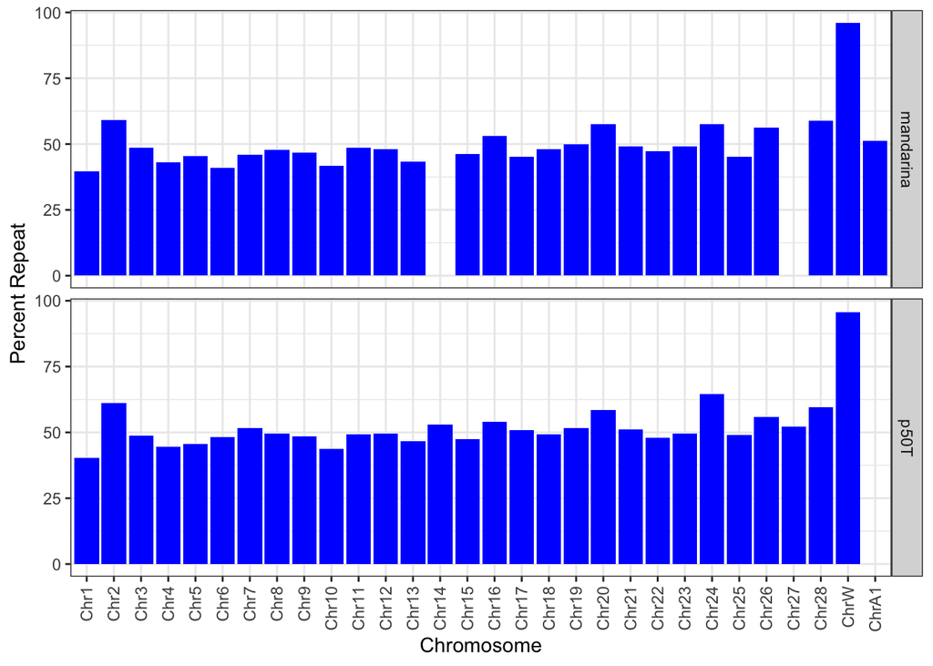

```r
ggplot(data = observedChr, aes(x = group, y = repeat_percent)) +
  geom_bar( stat = "identity", fill = "blue") +
  facet_grid( rows = "assembly") + theme_bw() +
  xlab("Chromosome") + ylab("Percent Repeat") +
  theme(axis.text.x = element_text(angle = 90, vjust = 0.5, hjust = 1))
```

### 5.4.2 Fraction repeat by ZWA

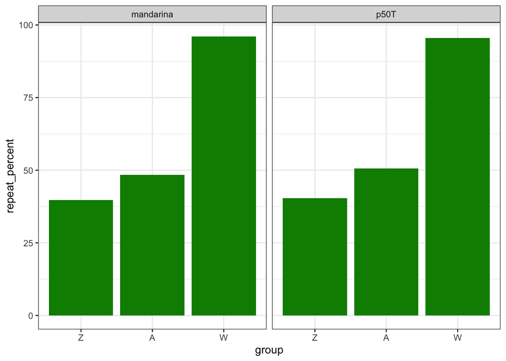

```r
ggplot(data = observedZWA, aes(x = group, y = repeat_percent)) +
  geom_bar( stat = "identity", fill = "green4") +
  facet_wrap( ~ assembly) + theme_bw()
```

```r
moriBlocks$block_family <- moriBlocks$block_family |>
  dplyr::mutate(
    zwa = dplyr::case_when(
      chromosome == "ChrW" ~ "W",
      chromosome == "Chr1" ~ "Z",
      TRUE ~ "A"
    ),
    zwa = factor(zwa, levels = c("W", "A", "Z"))
  )


mandBlocks$block_family <- mandBlocks$block_family |>
  dplyr::mutate(
    zwa = dplyr::case_when(
      chromosome == "ChrW" ~ "W",
      chromosome == "Chr1" ~ "Z",
      TRUE ~ "A"
    ),
    zwa = factor(zwa, levels = c("W", "A", "Z"))
  )

family <- rbind(moriBlocks$block_family, mandBlocks$block_family)
```

```r
repclasslevels <- c("Satellite",  "Helitron" , "DNA", "SINE", "LINE", "tRNA",
                    "Penelope","LTR" ,  "Unknown", "snRNA" )

## Repeat bp by chromosome type and repeat class
class_bp <- family |>
  dplyr::group_by(assembly, zwa, repeat_class) |>
  dplyr::summarize(
    repeat_bp = sum(overlap_bp),
    .groups = "drop"
  ) |>
  dplyr::mutate(repeat_class = factor(repeat_class, levels = repclasslevels))

## Total physical sequence represented by each chromosome type
chr_bp <- observedZWA |>
  dplyr::group_by(assembly, group) |>
  dplyr::summarize(
    chromosome_bp = sum(block_bp),
    .groups = "drop"
  ) |>
  dplyr::rename( zwa = group)

## Combine numerator and denominator
bmRepeatClass <- class_bp |>
  dplyr::left_join(chr_bp, by = c("assembly", "zwa")) |>
  dplyr::mutate(Taxon = ifelse (assembly == "p50T", "mori", "mandarina")) |>
  dplyr::mutate(
    repeat_fraction = repeat_bp / chromosome_bp,
    repeat_percent  = 100 * repeat_fraction
  ) |>
  dplyr::filter(repeat_class != "snRNA" & repeat_class  != "tRNA") |>
  dplyr::mutate(repeat_class = relevel(factor(repeat_class) , "Satellite",  "Helitron" , "DNA", "SINE",  "LINE", "Penelope","LTR" ,  "Unknown"))
```

```r
Repeat_colors <- c(
  Satellite = "#88CCEE",
  Helitron = "#117733",
  DNA = "#332288",
  SINE = "#AA4499",
  LINE = "#999933",
  Penelope = "#6699CC",
  LTR =  "#661100",
  Unknown = "#888888"
)
```

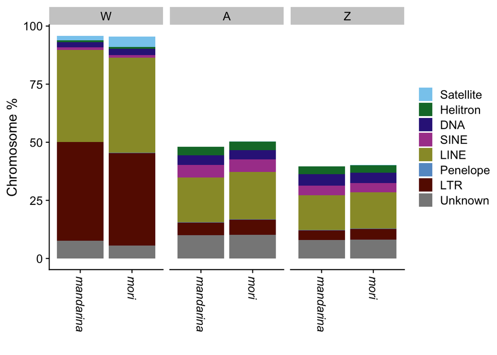

```r
plotRepeatTypes <- ggplot(
  bmRepeatClass,
  aes(
    x = Taxon,
    y = repeat_percent,
    fill = repeat_class
  )
) +
  geom_col() +
  labs(
    x = "",
    y = "Chromosome %",
    fill = "Repeat class"
  ) +
  scale_fill_manual (values = Repeat_colors) +
  theme_cowplot() +
  theme(legend.title = element_blank()) +
  theme (axis.text.x = element_text(angle = 270, vjust = 0.5, hjust =0)) +
  theme (axis.text.x = element_text(face = "italic")) +
  facet_wrap(~zwa)


plot(plotRepeatTypes)
```

### 5.4.3 Richness by chromosome

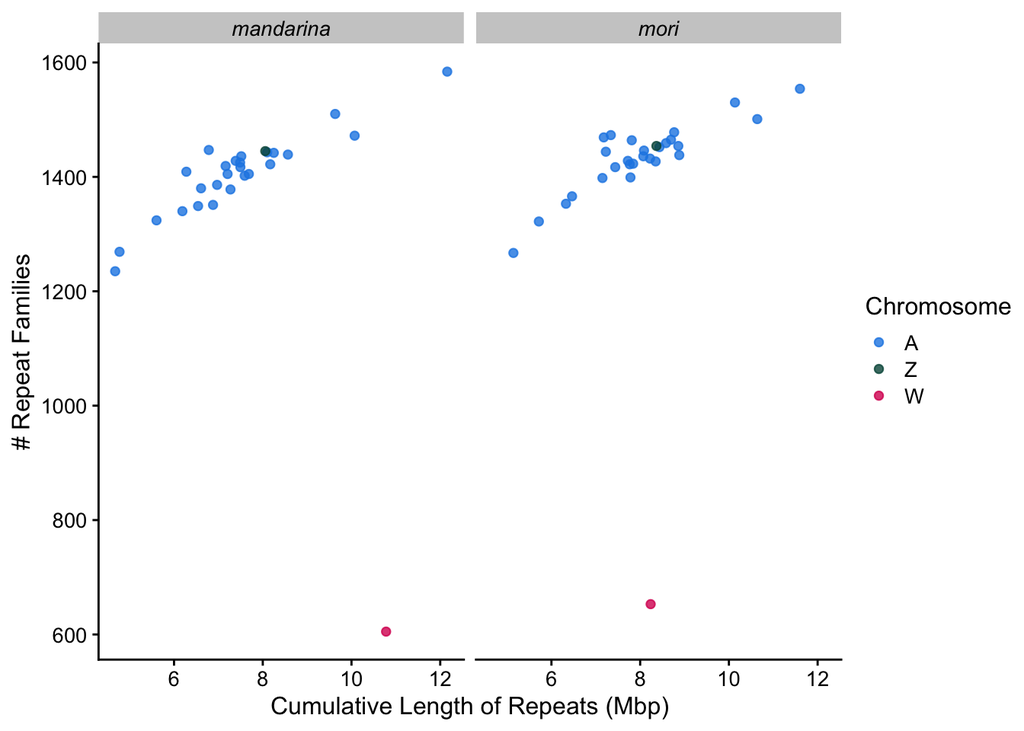

```r
zwalevel <-  c( "A", "Z", "W" )

moriRichObs<- moriRichObs |>
  dplyr::mutate(
    zwa = dplyr::case_when(
      group == "ChrW" ~ "W",
      group == "Chr1" ~ "Z",
      TRUE ~ "A"
    ),
    zwa = factor(zwa, levels = zwalevel)
  )

mandRichObs<- mandRichObs |>
  dplyr::mutate(
    zwa = dplyr::case_when(
      group == "ChrW" ~ "W",
      group == "Chr1" ~ "Z",
      TRUE ~ "A"
    ),
    zwa = factor(zwa, levels = zwalevel)
  )

comboRichObs <- rbind(moriRichObs, mandRichObs) |>
  dplyr::mutate(Taxon = ifelse (assembly == "p50T", "mori", "mandarina"))

#zwacols <- c("green4","blue", "red")
zwacols <- c("#1E88E5", "#005447",   "#D81B60" )

# order to address overplotting of points
plotRichness <- ggplot(data = comboRichObs[order(comboRichObs$zwa),],
       aes(x = repeat_bp/1e6, y = richness, col = zwa)) +
  geom_point(alpha = 0.8) + scale_color_manual (values = zwacols) +
  theme_cowplot(12) +
  theme(strip.text = element_text(face = "italic")) +
  labs(x = "Cumulative Length of Repeats (Mbp)",
       y = "# Repeat Families",
       col = "Chromosome" ) +
  facet_wrap( ~ Taxon)

plot(plotRichness)
```

# 6 Bootstrapping

We can use the dedicated boostrapping function to do resampling of the genomic blocks for each chromosome. The `blocks` structure means each chromosome has **N** blocks, each of the roughly the same target window size (e.g. 100 Kbp). For each bootstrap, we resample with replacement each chromosome for **N** blocks, effectively recreating a genome’s worth of data in each round of sampling.

```r
moriBoot <- bootstrap_block_draws(
  moriBlocks,
  n_boot = 5000,
  seed = 1234
)

mandBoot <- bootstrap_block_draws(
  mandBlocks,
  n_boot = 5000,
  seed = 5678
)
```

## 6.1 Repeat Fractions

Once we have the draws of sampled windows, we can use these to generate values per chromosome, or groupings of chromosomes, for instance `ZWA`.

### 6.1.1 mori

```r
moriFrac <- bootstrap_fraction(block_data = moriBlocks,
                               bootstrap_draws = moriBoot)


moriFracZWA <- bootstrap_fraction(block_data = moriBlocks,
                                  bootstrap_draws = moriBoot,
                                  chromosome_groups = morizwa)
```

### 6.1.2 mandarina

```r
mandFrac <- bootstrap_fraction(block_data = mandBlocks,
                               bootstrap_draws = mandBoot)


mandFracZWA <- bootstrap_fraction(block_data = mandBlocks,
                                  bootstrap_draws = mandBoot,
                                  chromosome_groups = mandzwa)
```

## 6.2 Repeat Richness

We can do the same thing for richness, generating values for bootstrapped replicates of richness by chromosome, or groupings of chromosomes. In this case, we use the Horvitz-Thompson correction for unequal probability sampling, since bootstrap samples of a chromosome will likely be less than the whole chromosome, and never greater.

### 6.2.1 mori

```r
moriRich <- bootstrap_richness(block_data = moriBlocks,
                               bootstrap_draws = moriBoot)

#ZWA is not needed for richness in our analysis,
# but it can be done by the function...
moriRichZWA <- bootstrap_richness(block_data = moriBlocks,
                                  bootstrap_draws = moriBoot,
                                  chromosome_groups = morizwa)
```

### 6.2.2 mandarina

```r
mandRich <- bootstrap_richness(block_data = mandBlocks,
                               bootstrap_draws = mandBoot)

#ZWA is not needed for richness in our analysis,
# but it can be done by the function...
mandRichZWA <- bootstrap_richness(block_data = mandBlocks,
                                  bootstrap_draws = mandBoot,
                                  chromosome_groups = mandzwa)
```

# 7 Confidence intervals

With the bootstrapped samples calculated, we can use these values to generate CIs .

## 7.1 Repeat Fraction

### 7.1.1 By Chromosome

```r
moriFracCI <- bootstrap_ci(bootstrap_data = moriFrac,
                           value = "repeat_fraction",
                           observed = moriFracObs)


mandFracCI <- bootstrap_ci(bootstrap_data = mandFrac,
                           value = "repeat_fraction",
                           observed = mandFracObs)


observedChrCI <- rbind(moriFracCI, mandFracCI)  |>
  dplyr::mutate(Taxon = ifelse (assembly == "p50T", "mori", "mandarina"))

write.csv(observedChrCI,    file = "results_bs/FractionObsCI-CHR.csv", row.names = F)
```

```r
kbl(observedChrCI, caption = "Repeat Fraction CIs by Chromosome") |>
  kable_styling(bootstrap_options = c("striped", "hover", "condensed"),
                fixed_thead = T) |>
  scroll_box(width = "100%", height = "400px")
```

Repeat Fraction CIs by Chromosome

| assembly | level | group | statistic | n_boot | bootstrap_mean | bootstrap_median | bootstrap_sd | ci_lower | ci_upper | observed | Taxon |
| --- | --- | --- | --- | --- | --- | --- | --- | --- | --- | --- | --- |
| p50T | chromosome | Chr1 | repeat_fraction | 5000 | 0.4040913 | 0.4040487 | 0.0062192 | 0.3922565 | 0.4162520 | 0.4040826 | mori |
| p50T | chromosome | Chr2 | repeat_fraction | 5000 | 0.6124103 | 0.6122394 | 0.0109911 | 0.5905362 | 0.6337193 | 0.6125346 | mori |
| p50T | chromosome | Chr3 | repeat_fraction | 5000 | 0.4881191 | 0.4879309 | 0.0069582 | 0.4746243 | 0.5018727 | 0.4880430 | mori |
| p50T | chromosome | Chr4 | repeat_fraction | 5000 | 0.4467043 | 0.4464711 | 0.0073269 | 0.4329610 | 0.4615960 | 0.4466967 | mori |
| p50T | chromosome | Chr5 | repeat_fraction | 5000 | 0.4570339 | 0.4570229 | 0.0067710 | 0.4439706 | 0.4705484 | 0.4571793 | mori |
| p50T | chromosome | Chr6 | repeat_fraction | 5000 | 0.4818846 | 0.4818919 | 0.0094235 | 0.4635070 | 0.5006289 | 0.4817352 | mori |
| p50T | chromosome | Chr7 | repeat_fraction | 5000 | 0.5154791 | 0.5152854 | 0.0083155 | 0.4995253 | 0.5321072 | 0.5154713 | mori |
| p50T | chromosome | Chr8 | repeat_fraction | 5000 | 0.4965244 | 0.4964519 | 0.0070132 | 0.4830266 | 0.5106722 | 0.4965474 | mori |
| p50T | chromosome | Chr9 | repeat_fraction | 5000 | 0.4846346 | 0.4844841 | 0.0056805 | 0.4736378 | 0.4954546 | 0.4847160 | mori |
| p50T | chromosome | Chr10 | repeat_fraction | 5000 | 0.4377991 | 0.4376637 | 0.0075450 | 0.4233546 | 0.4529477 | 0.4376663 | mori |
| p50T | chromosome | Chr11 | repeat_fraction | 5000 | 0.4934018 | 0.4932258 | 0.0089474 | 0.4764357 | 0.5111037 | 0.4933747 | mori |
| p50T | chromosome | Chr12 | repeat_fraction | 5000 | 0.4965173 | 0.4964151 | 0.0086282 | 0.4798517 | 0.5139875 | 0.4965240 | mori |
| p50T | chromosome | Chr13 | repeat_fraction | 5000 | 0.4674848 | 0.4674747 | 0.0064621 | 0.4552428 | 0.4802822 | 0.4674517 | mori |
| p50T | chromosome | Chr14 | repeat_fraction | 5000 | 0.5310714 | 0.5312116 | 0.0078137 | 0.5155575 | 0.5460608 | 0.5310092 | mori |
| p50T | chromosome | Chr15 | repeat_fraction | 5000 | 0.4733405 | 0.4733493 | 0.0066249 | 0.4603814 | 0.4863719 | 0.4732082 | mori |
| p50T | chromosome | Chr16 | repeat_fraction | 5000 | 0.5410070 | 0.5407160 | 0.0078401 | 0.5260438 | 0.5570879 | 0.5409587 | mori |
| p50T | chromosome | Chr17 | repeat_fraction | 5000 | 0.5073987 | 0.5074839 | 0.0064838 | 0.4948090 | 0.5204773 | 0.5073620 | mori |
| p50T | chromosome | Chr18 | repeat_fraction | 5000 | 0.4939974 | 0.4938029 | 0.0085080 | 0.4776938 | 0.5115520 | 0.4939484 | mori |
| p50T | chromosome | Chr19 | repeat_fraction | 5000 | 0.5171989 | 0.5172077 | 0.0080334 | 0.5015158 | 0.5331000 | 0.5171252 | mori |
| p50T | chromosome | Chr20 | repeat_fraction | 5000 | 0.5849960 | 0.5849231 | 0.0088666 | 0.5677661 | 0.6023698 | 0.5850869 | mori |
| p50T | chromosome | Chr21 | repeat_fraction | 5000 | 0.5103631 | 0.5104661 | 0.0063142 | 0.4979882 | 0.5226585 | 0.5102373 | mori |
| p50T | chromosome | Chr22 | repeat_fraction | 5000 | 0.4798726 | 0.4797037 | 0.0075890 | 0.4650317 | 0.4951644 | 0.4798363 | mori |
| p50T | chromosome | Chr23 | repeat_fraction | 5000 | 0.4941730 | 0.4941380 | 0.0073147 | 0.4800437 | 0.5090726 | 0.4941424 | mori |
| p50T | chromosome | Chr24 | repeat_fraction | 5000 | 0.6445981 | 0.6443880 | 0.0082253 | 0.6290111 | 0.6612758 | 0.6445094 | mori |
| p50T | chromosome | Chr25 | repeat_fraction | 5000 | 0.4899992 | 0.4900110 | 0.0069058 | 0.4766652 | 0.5034485 | 0.4898823 | mori |
| p50T | chromosome | Chr26 | repeat_fraction | 5000 | 0.5586973 | 0.5586120 | 0.0074447 | 0.5444716 | 0.5736615 | 0.5584274 | mori |
| p50T | chromosome | Chr27 | repeat_fraction | 5000 | 0.5226672 | 0.5228316 | 0.0081810 | 0.5070087 | 0.5385349 | 0.5225303 | mori |
| p50T | chromosome | Chr28 | repeat_fraction | 5000 | 0.5955431 | 0.5955585 | 0.0067554 | 0.5822703 | 0.6089274 | 0.5955609 | mori |
| p50T | chromosome | ChrW | repeat_fraction | 5000 | 0.9557391 | 0.9559469 | 0.0046259 | 0.9463524 | 0.9644093 | 0.9556682 | mori |
| mandarina | chromosome | Chr1 | repeat_fraction | 5000 | 0.3975462 | 0.3974517 | 0.0055145 | 0.3866797 | 0.4086656 | 0.3974438 | mandarina |
| mandarina | chromosome | Chr2 | repeat_fraction | 5000 | 0.5916064 | 0.5920356 | 0.0127866 | 0.5650635 | 0.6152429 | 0.5915447 | mandarina |
| mandarina | chromosome | Chr3 | repeat_fraction | 5000 | 0.4858723 | 0.4858107 | 0.0070092 | 0.4723009 | 0.4998873 | 0.4860285 | mandarina |
| mandarina | chromosome | Chr4 | repeat_fraction | 5000 | 0.4305809 | 0.4305220 | 0.0068285 | 0.4174736 | 0.4445188 | 0.4306113 | mandarina |
| mandarina | chromosome | Chr5 | repeat_fraction | 5000 | 0.4535136 | 0.4534805 | 0.0064215 | 0.4409619 | 0.4663719 | 0.4534047 | mandarina |
| mandarina | chromosome | Chr6 | repeat_fraction | 5000 | 0.4084665 | 0.4086747 | 0.0154574 | 0.3776251 | 0.4382097 | 0.4082465 | mandarina |
| mandarina | chromosome | Chr7 | repeat_fraction | 5000 | 0.4592321 | 0.4595299 | 0.0143899 | 0.4299430 | 0.4854634 | 0.4589397 | mandarina |
| mandarina | chromosome | Chr8 | repeat_fraction | 5000 | 0.4791699 | 0.4791273 | 0.0069074 | 0.4660745 | 0.4925838 | 0.4792396 | mandarina |
| mandarina | chromosome | Chr9 | repeat_fraction | 5000 | 0.4677448 | 0.4678258 | 0.0074325 | 0.4524887 | 0.4819244 | 0.4677455 | mandarina |
| mandarina | chromosome | Chr10 | repeat_fraction | 5000 | 0.4173433 | 0.4176183 | 0.0081196 | 0.4008806 | 0.4323299 | 0.4174274 | mandarina |
| mandarina | chromosome | Chr11 | repeat_fraction | 5000 | 0.4863416 | 0.4861868 | 0.0082808 | 0.4700433 | 0.5023450 | 0.4863462 | mandarina |
| mandarina | chromosome | Chr12 | repeat_fraction | 5000 | 0.4795863 | 0.4796287 | 0.0072005 | 0.4654287 | 0.4936985 | 0.4798061 | mandarina |
| mandarina | chromosome | Chr13 | repeat_fraction | 5000 | 0.4330610 | 0.4332322 | 0.0099736 | 0.4134167 | 0.4519192 | 0.4331977 | mandarina |
| mandarina | chromosome | Chr15 | repeat_fraction | 5000 | 0.4633484 | 0.4633181 | 0.0062794 | 0.4506730 | 0.4756382 | 0.4634508 | mandarina |
| mandarina | chromosome | Chr16 | repeat_fraction | 5000 | 0.5294687 | 0.5295343 | 0.0068715 | 0.5162205 | 0.5430892 | 0.5294271 | mandarina |
| mandarina | chromosome | Chr17 | repeat_fraction | 5000 | 0.4527528 | 0.4528519 | 0.0120627 | 0.4290341 | 0.4765533 | 0.4528287 | mandarina |
| mandarina | chromosome | Chr18 | repeat_fraction | 5000 | 0.4796053 | 0.4795312 | 0.0075266 | 0.4650917 | 0.4943665 | 0.4795240 | mandarina |
| mandarina | chromosome | Chr19 | repeat_fraction | 5000 | 0.4980362 | 0.4980502 | 0.0064916 | 0.4852023 | 0.5108108 | 0.4980350 | mandarina |
| mandarina | chromosome | Chr20 | repeat_fraction | 5000 | 0.5755612 | 0.5756596 | 0.0084740 | 0.5587424 | 0.5917589 | 0.5756396 | mandarina |
| mandarina | chromosome | Chr21 | repeat_fraction | 5000 | 0.4924213 | 0.4924782 | 0.0065946 | 0.4793631 | 0.5050313 | 0.4922446 | mandarina |
| mandarina | chromosome | Chr22 | repeat_fraction | 5000 | 0.4715367 | 0.4714451 | 0.0071046 | 0.4580166 | 0.4858230 | 0.4715972 | mandarina |
| mandarina | chromosome | Chr23 | repeat_fraction | 5000 | 0.4919094 | 0.4918769 | 0.0073172 | 0.4777326 | 0.5064886 | 0.4922024 | mandarina |
| mandarina | chromosome | Chr24 | repeat_fraction | 5000 | 0.5766229 | 0.5769265 | 0.0179184 | 0.5403501 | 0.6103822 | 0.5765808 | mandarina |
| mandarina | chromosome | Chr25 | repeat_fraction | 5000 | 0.4518875 | 0.4521054 | 0.0110403 | 0.4292530 | 0.4728613 | 0.4518209 | mandarina |
| mandarina | chromosome | Chr26 | repeat_fraction | 5000 | 0.5615891 | 0.5615442 | 0.0076860 | 0.5466333 | 0.5764659 | 0.5616905 | mandarina |
| mandarina | chromosome | Chr28 | repeat_fraction | 5000 | 0.5897110 | 0.5897396 | 0.0065647 | 0.5766224 | 0.6025185 | 0.5897309 | mandarina |
| mandarina | chromosome | ChrA1 | repeat_fraction | 5000 | 0.5128553 | 0.5128253 | 0.0058347 | 0.5015804 | 0.5243624 | 0.5128255 | mandarina |
| mandarina | chromosome | ChrW | repeat_fraction | 5000 | 0.9606127 | 0.9607399 | 0.0038378 | 0.9528086 | 0.9675136 | 0.9606610 | mandarina |

#### 7.1.1.1 Plot Fraction by Chromosome

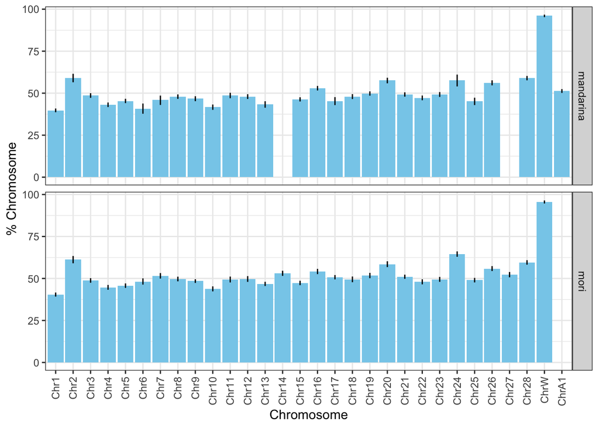

```r
plotFracByChromCI <- ggplot(data = observedChrCI, aes(x = group, y = observed * 100)) +
  geom_bar( stat = "identity", fill = "skyblue") +
  geom_linerange( aes(x=group, ymin=ci_lower*100, ymax=ci_upper*100)) +
  xlab("Chromosome") + ylab("% Chromosome") +
  facet_grid( "Taxon" ) +
  theme_bw() +
  theme(axis.text.x = element_text(angle = 90, vjust = 0.5, hjust = 1))

plot(plotFracByChromCI)
```

```r
ggsave(plot = plotFracByChromCI,
       filename = "results_bs/FractionByChromCI.jpg",
      device = ragg::agg_tiff,
      width  = 300, height = 180, units = "mm",
      res    = 300,
      compression = "lzw",
      bg = "white",
      scale = .8)
```

### 7.1.2 By ZWA

Let’s do the same thing for the ZWA partitions

```r
moriFracZWACI <- bootstrap_ci(bootstrap_data = moriFracZWA,
                           value = "repeat_fraction",
                           observed = moriFracObsZWA)

mandFracZWACI <- bootstrap_ci(bootstrap_data = mandFracZWA,
                           value = "repeat_fraction",
                           observed = mandFracObsZWA)

obsFracZWACI <- rbind(moriFracZWACI, mandFracZWACI) |>
  dplyr::mutate(Taxon = ifelse (assembly == "p50T", "mori", "mandarina")) |>
  dplyr::mutate(zwa = factor(group, levels = c("W", "A", "Z")))


write.csv(obsFracZWACI, file = "results_bs/FractionObsCI-ZWA.csv", row.names = F)
```

And we can plot these values with error bars for CIs

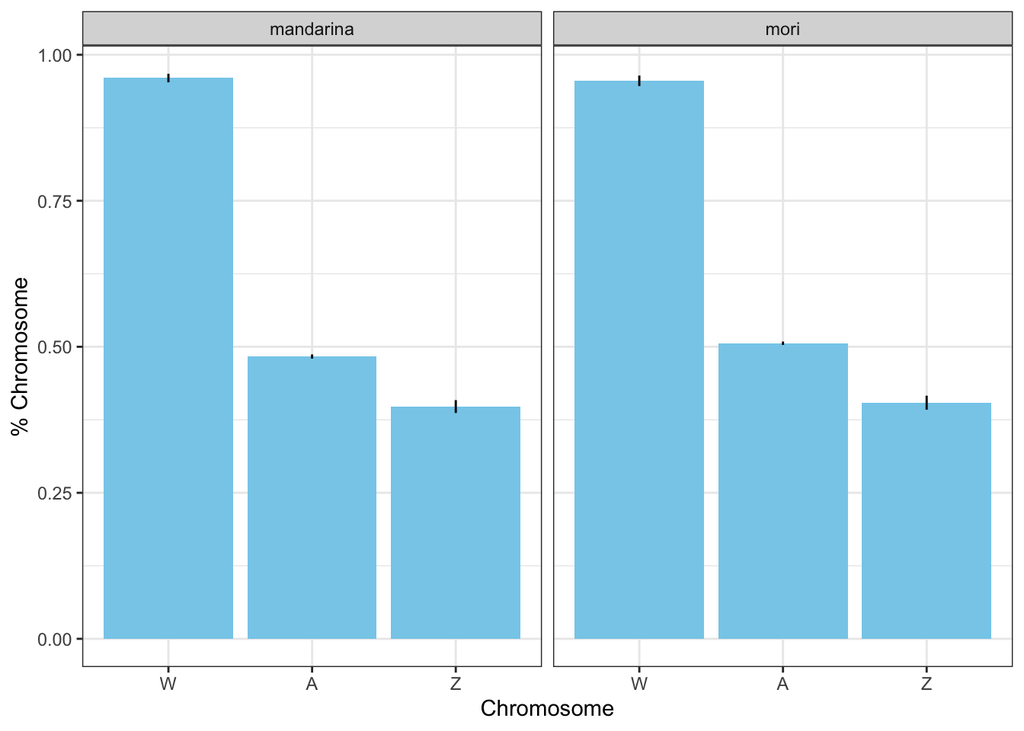

```r
plotFracByZWACI <- ggplot(data = obsFracZWACI,
                          aes(x = zwa, y = observed)) +
  geom_bar( stat = "identity", fill = "skyblue") +
  geom_linerange( aes(x=group, ymin=ci_lower, ymax=ci_upper)) +
  xlab("Chromosome") + ylab("% Chromosome") +
  facet_wrap( ~ Taxon ) +
  theme_bw()

plotFracByZWACI
```

```r
ggsave(plot = plotFracByZWACI,
       filename = "results_bs/FractionByZWACI.jpg",
      device = ragg::agg_tiff,
      width  = 200, height = 120, units = "mm",
      res    = 300,
      compression = "lzw",
      bg = "white",
      scale = .8)
```

## 7.2 Repeat Richness

### 7.2.1 By Chromosome

```r
moriRichCI <- bootstrap_ci(bootstrap_data = moriRich,
                           value = "richness_corrected",
                           observed = moriRichObs,
                           observed_value = "richness")

mandRichCI <- bootstrap_ci(bootstrap_data = mandRich,
                           value = "richness_corrected",
                           observed = mandRichObs,
                           observed_value = "richness")
```

Modify richness CIs for plotting

```r
comboRichCI <- rbind(moriRichCI, mandRichCI) |>
  dplyr::mutate(
    zwa = dplyr::case_when(
      group == "ChrW" ~ "W",
      group == "Chr1" ~ "Z",
      TRUE ~ "A"
    ),
    zwa = factor(zwa, levels = c("A", "Z", "W"))
  ) |>
  dplyr::arrange(zwa)

write.csv(x = comboRichCI, file = "results_bs/RichnessObsCHR-CI.csv", row.names = F)
```

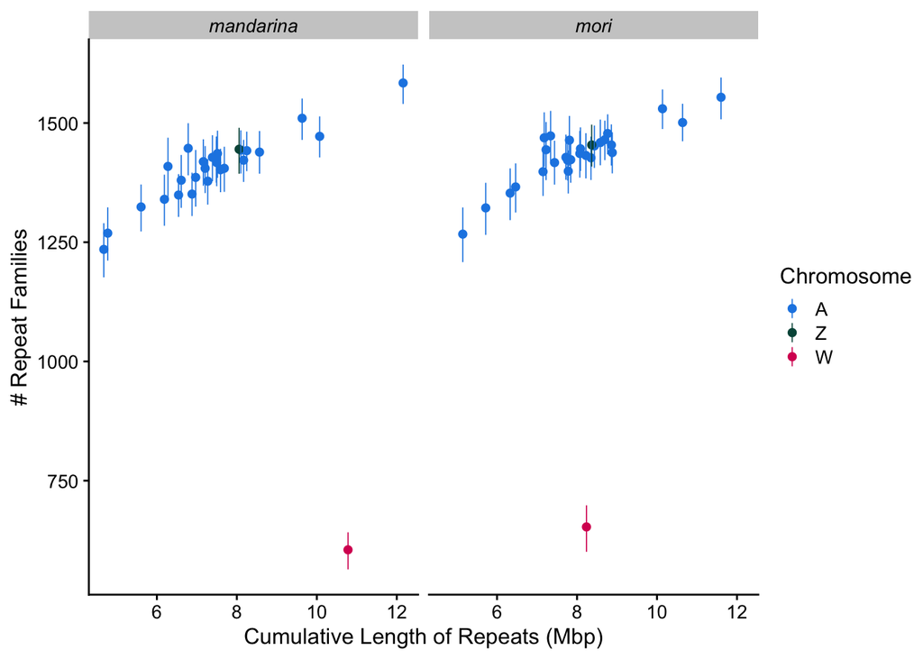

```r
plotRichCI <- ggplot(data = comboRichObs[order(comboRichObs$zwa),],
       aes(x = repeat_bp/1e6, y = richness, col = zwa)) +
  geom_point() + scale_color_manual (values = zwacols) +
  geom_linerange( aes(x=repeat_bp/1e6, ymin=comboRichCI$ci_lower,
                      ymax=comboRichCI$ci_upper), linewidth = 0.3) +
  theme_cowplot(12) +
  theme(strip.text = element_text(face = "italic")) +
  labs(x = "Cumulative Length of Repeats (Mbp)",
       y = "# Repeat Families",
       col = "Chromosome" ) +
  facet_wrap( ~ Taxon)


plotRichCI
```

# 8 Shared repeat content

## 8.1 Observed similarity metrics

Get counts and similarity measures of repeats shared between assemblies, by chromosome

```r
sharedObs <- observed_shared(moriBlocks, mandBlocks)
```

```
Excluded from block_data_1 because no matching chromosome name was present in block_data_2: Chr14, Chr27
```

```
Excluded from block_data_2 because no matching chromosome name was present in block_data_1: ChrA1
```

```r
kbl(sharedObs, caption = "Observed shared repeats") |>
  kable_styling(bootstrap_options = c("striped", "hover", "condensed"),
                fixed_thead = T) |>
  scroll_box(width = "100%", height = "400px")
```

Observed shared repeats

| assembly_1 | assembly_2 | chromosome | block_bp_1 | block_bp_2 | repeat_bp_1 | repeat_bp_2 | richness_1 | richness_2 | shared | unique_1 | unique_2 | union | jaccard | bray_curtis_dissimilarity | bray_curtis_similarity |
| --- | --- | --- | --- | --- | --- | --- | --- | --- | --- | --- | --- | --- | --- | --- | --- |
| p50T | mandarina | Chr1 | 20704013 | 20271500 | 8366131 | 8056781 | 1454 | 1445 | 1371 | 83 | 74 | 1528 | 0.8972513 | 0.1425970 | 0.8574030 |
| p50T | mandarina | Chr2 | 8395788 | 8066242 | 5142711 | 4771543 | 1267 | 1269 | 1148 | 119 | 121 | 1388 | 0.8270893 | 0.1566246 | 0.8433754 |
| p50T | mandarina | Chr3 | 15240185 | 15204957 | 7437866 | 7390043 | 1417 | 1428 | 1318 | 99 | 110 | 1527 | 0.8631303 | 0.1567327 | 0.8432673 |
| p50T | mandarina | Chr4 | 18881147 | 17407838 | 8434147 | 7496012 | 1452 | 1417 | 1338 | 114 | 79 | 1531 | 0.8739386 | 0.1874602 | 0.8125398 |
| p50T | mandarina | Chr5 | 19018680 | 18016803 | 8694947 | 8168904 | 1465 | 1422 | 1354 | 111 | 68 | 1533 | 0.8832355 | 0.1514367 | 0.8485633 |
| p50T | mandarina | Chr6 | 16753471 | 16189044 | 8070737 | 6609120 | 1436 | 1380 | 1293 | 143 | 87 | 1523 | 0.8489823 | 0.1775977 | 0.8224023 |
| p50T | mandarina | Chr7 | 14018603 | 13678471 | 7226188 | 6277593 | 1444 | 1409 | 1334 | 110 | 75 | 1519 | 0.8782093 | 0.1607909 | 0.8392091 |
| p50T | mandarina | Chr8 | 16284022 | 15682612 | 8085788 | 7515729 | 1446 | 1436 | 1352 | 94 | 84 | 1530 | 0.8836601 | 0.1706523 | 0.8293477 |
| p50T | mandarina | Chr9 | 16963179 | 16433000 | 8222325 | 7686462 | 1432 | 1405 | 1324 | 108 | 81 | 1513 | 0.8750826 | 0.1568635 | 0.8431365 |
| p50T | mandarina | Chr10 | 17741521 | 15672897 | 7764865 | 6542297 | 1422 | 1349 | 1275 | 147 | 74 | 1496 | 0.8522727 | 0.1664686 | 0.8335314 |
| p50T | mandarina | Chr11 | 20545916 | 19805820 | 10136836 | 9632485 | 1530 | 1510 | 1445 | 85 | 65 | 1595 | 0.9059561 | 0.1426613 | 0.8573387 |
| p50T | mandarina | Chr12 | 17843192 | 16879110 | 8859573 | 8098700 | 1454 | 1443 | 1353 | 101 | 90 | 1544 | 0.8762953 | 0.1753685 | 0.8246315 |
| p50T | mandarina | Chr13 | 17860386 | 16787500 | 8348867 | 7272307 | 1427 | 1378 | 1308 | 119 | 70 | 1497 | 0.8737475 | 0.1564110 | 0.8435890 |
| p50T | mandarina | Chr15 | 18525219 | 17797070 | 8766285 | 8248066 | 1478 | 1442 | 1372 | 106 | 70 | 1548 | 0.8863049 | 0.1599056 | 0.8400944 |
| p50T | mandarina | Chr16 | 14437843 | 14145920 | 7810277 | 7489233 | 1464 | 1425 | 1344 | 120 | 81 | 1545 | 0.8699029 | 0.1612825 | 0.8387175 |
| p50T | mandarina | Chr17 | 16917329 | 16766812 | 8583210 | 7592493 | 1459 | 1402 | 1329 | 130 | 73 | 1532 | 0.8674935 | 0.1587874 | 0.8412126 |
| p50T | mandarina | Chr18 | 15752945 | 14345499 | 7781142 | 6879011 | 1399 | 1351 | 1263 | 136 | 88 | 1487 | 0.8493611 | 0.1644779 | 0.8355221 |
| p50T | mandarina | Chr19 | 14933993 | 14382000 | 7722744 | 7162740 | 1428 | 1419 | 1332 | 96 | 87 | 1515 | 0.8792079 | 0.1791675 | 0.8208325 |
| p50T | mandarina | Chr20 | 12542456 | 11784488 | 7338427 | 6783618 | 1473 | 1447 | 1373 | 100 | 74 | 1547 | 0.8875242 | 0.1684834 | 0.8315166 |
| p50T | mandarina | Chr21 | 15369122 | 14641104 | 7841900 | 7207005 | 1423 | 1405 | 1321 | 102 | 84 | 1507 | 0.8765760 | 0.1545178 | 0.8454822 |
| p50T | mandarina | Chr22 | 18509390 | 18165971 | 8881478 | 8567021 | 1438 | 1439 | 1350 | 88 | 89 | 1527 | 0.8840864 | 0.1606296 | 0.8393704 |
| p50T | mandarina | Chr23 | 21531069 | 20461145 | 10639414 | 10071025 | 1501 | 1472 | 1400 | 101 | 72 | 1573 | 0.8900191 | 0.1438300 | 0.8561700 |
| p50T | mandarina | Chr24 | 17999841 | 12089975 | 11601066 | 6970847 | 1554 | 1386 | 1346 | 208 | 40 | 1594 | 0.8444166 | 0.1817232 | 0.8182768 |
| p50T | mandarina | Chr25 | 14595103 | 12405635 | 7149883 | 5605125 | 1398 | 1324 | 1252 | 146 | 72 | 1470 | 0.8517007 | 0.1762271 | 0.8237729 |
| p50T | mandarina | Chr26 | 11576346 | 8320000 | 6464549 | 4673265 | 1366 | 1235 | 1167 | 199 | 68 | 1434 | 0.8138075 | 0.1579996 | 0.8420004 |
| p50T | mandarina | Chr28 | 10624740 | 10493838 | 6327680 | 6188541 | 1353 | 1340 | 1233 | 120 | 107 | 1460 | 0.8445205 | 0.1540590 | 0.8459410 |
| p50T | mandarina | ChrW | 8618457 | 11221128 | 8236385 | 10779700 | 653 | 605 | 484 | 169 | 121 | 774 | 0.6253230 | 0.3339209 | 0.6660791 |

```r
write.csv(x = sharedObs, file = "SharedRepeatsObserved.csv", row.names = F)
```

Examine correlation between Jaccard and Bray-Curtis.

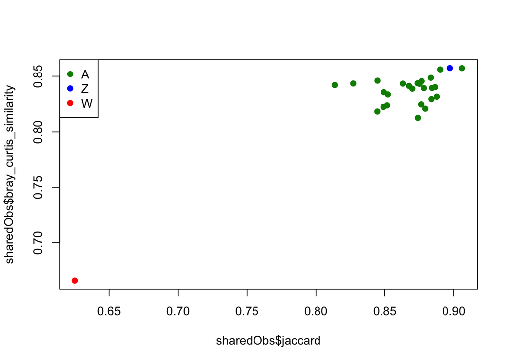

```r
zwacols <- c("green4","blue", "red")
plot(sharedObs$bray_curtis_similarity ~ sharedObs$jaccard,
     col = zwacols[c(2,rep(1,25),3)], pch = 19)
legend("topleft", col = zwacols, pch = 19, legend = c("A", "Z", "W"))
```

## 8.2 Bootstrap similarity metrics

Here we use the bootstrapped observations to calculate the shared repeats. We ignore the ‘fused’ chromosome between the two taxa, but calculate values for all others.

Since each bootstrap sample was done independently for each taxa, we can then just use each “pair” to calculate the overlap. This is what the `bootstrap_shared()` function does

```r
sharedBoot <- bootstrap_shared( block_data_1 = moriBlocks,
                                block_data_2 = mandBlocks,
                                bootstrap_draws_1 = moriBoot,
                                bootstrap_draws_2 = mandBoot)
```

```
Excluded from block_data_1 because no matching chromosome name was present in block_data_2: Chr14, Chr27
```

```
Excluded from block_data_2 because no matching chromosome name was present in block_data_1: ChrA1
```

With the bootstrapped similarity observations, we can plot the full distribution of bootstrapped values, and overlay the observed values as points.

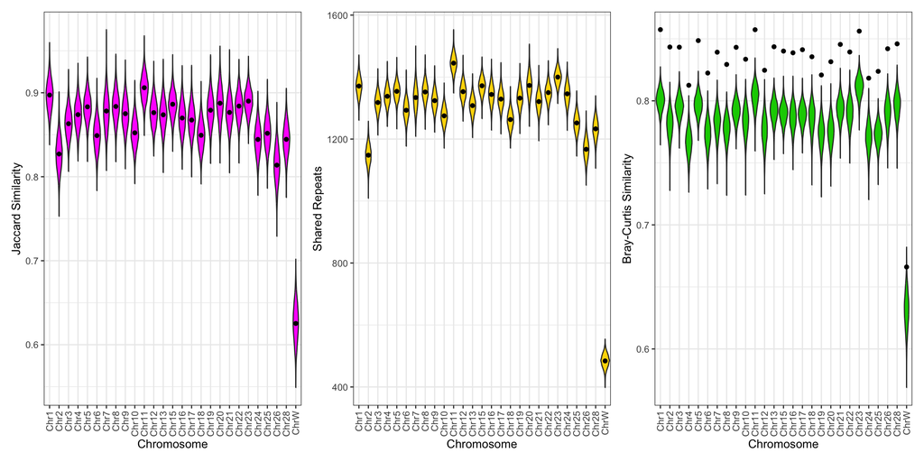

```r
plotJaccardViol <- ggplot(sharedBoot, aes(x = chromosome, y = jaccard_corrected)) +
  geom_violin(fill = "magenta") +
  geom_point(data = sharedObs, aes(x = chromosome, y = jaccard)) +
  ylab("Jaccard Similarity") + xlab("Chromosome") +
  theme_bw() +
  theme(axis.text.x = element_text(angle = 90, vjust = 0.5, hjust = 1))

plotSharedRepsViol <- ggplot(sharedBoot, aes(x = chromosome, y = shared_corrected)) +
  geom_violin(fill = "gold") +
  geom_point(data = sharedObs, aes(x = chromosome, y = shared)) +
  ylab("Shared Repeats") + xlab("Chromosome") +
  theme_bw() +
  theme(axis.text.x = element_text(angle = 90, vjust = 0.5, hjust = 1))


plotBrayViol <- ggplot(sharedBoot, aes(x = chromosome, y = bray_curtis_similarity)) +
  geom_violin(fill = "green3") +
  geom_point(data = sharedObs, aes(x = chromosome, y = bray_curtis_similarity)) +
  ylab("Bray-Curtis Similarity") + xlab("Chromosome") +
  theme_bw() +
  theme(axis.text.x = element_text(angle = 90, vjust = 0.5, hjust = 1))

plotJaccardViol + plotSharedRepsViol + plotBrayViol
```

Bray Curtis shows a consistent bias in the bootstraps (slightly less for W) for all chromosomes. This appears to be an issue with sampling in the bootstrap.

```r
bc_diag <- aggregate(
  bray_curtis_similarity ~ chromosome,
  data = sharedBoot,
  FUN = mean
)

names(bc_diag)[2] <- "bootstrap_mean"

bc_diag <- merge(
  bc_diag,
  sharedObs[, c("chromosome", "bray_curtis_similarity")],
  by = "chromosome"
)

bc_diag$bias <-
  bc_diag$bootstrap_mean -
  bc_diag$bray_curtis_similarity

bc_diag
```

```
   chromosome bootstrap_mean bray_curtis_similarity        bias
1        Chr1      0.8006658              0.8574030 -0.05673715
2       Chr10      0.7834132              0.8335314 -0.05011816
3       Chr11      0.8034854              0.8573387 -0.05385336
4       Chr12      0.7755672              0.8246315 -0.04906431
5       Chr13      0.7920205              0.8435890 -0.05156844
6       Chr15      0.7898625              0.8400944 -0.05023192
7       Chr16      0.7864095              0.8387175 -0.05230799
8       Chr17      0.7888779              0.8412126 -0.05233475
9       Chr18      0.7858114              0.8355221 -0.04971078
10      Chr19      0.7735324              0.8208325 -0.04730017
11       Chr2      0.7802844              0.8433754 -0.06309100
12      Chr20      0.7747188              0.8315166 -0.05679775
13      Chr21      0.7934613              0.8454822 -0.05202091
14      Chr22      0.7902875              0.8393704 -0.04908297
15      Chr23      0.8111476              0.8561700 -0.04502235
16      Chr24      0.7700273              0.8182768 -0.04824956
17      Chr25      0.7728377              0.8237729 -0.05093521
18      Chr26      0.7899133              0.8420004 -0.05208703
19      Chr28      0.7964754              0.8459410 -0.04946566
20       Chr3      0.7953810              0.8432673 -0.04788627
21       Chr4      0.7660272              0.8125398 -0.04651263
22       Chr5      0.7966334              0.8485633 -0.05192990
23       Chr6      0.7726257              0.8224023 -0.04977661
24       Chr7      0.7822666              0.8392091 -0.05694250
25       Chr8      0.7770425              0.8293477 -0.05230525
26       Chr9      0.7921273              0.8431365 -0.05100916
27       ChrW      0.6317711              0.6660791 -0.03430804
```

And we can get 95% CIs based on the bootstrapped values

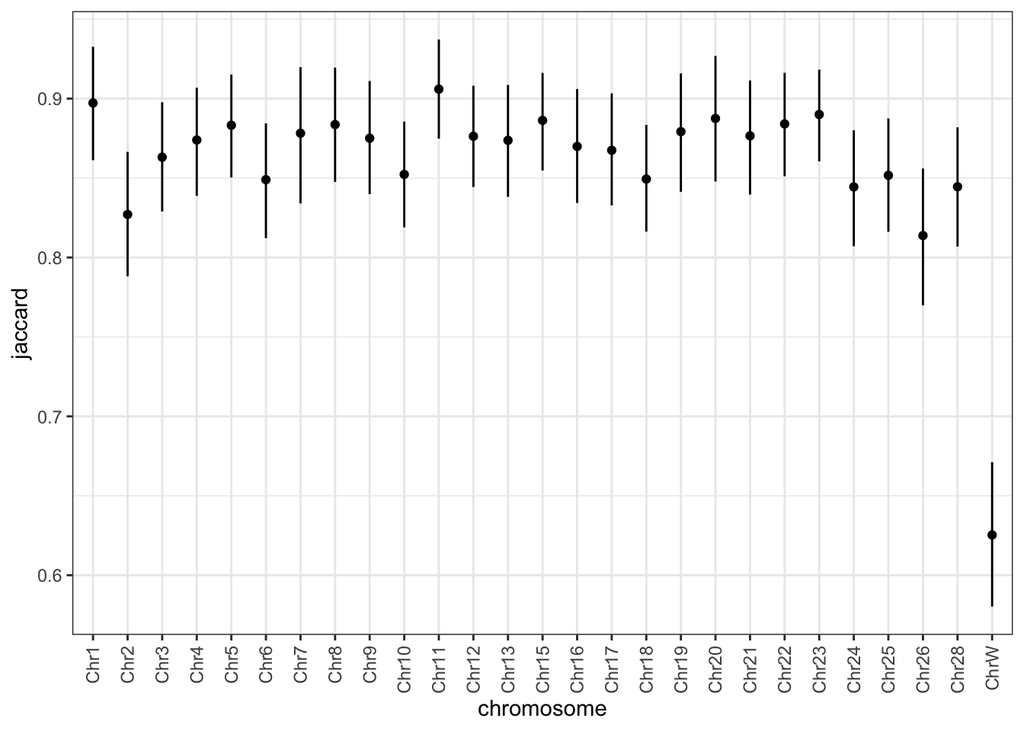

```r
jaccard_ci <- sharedBoot |>
  dplyr::group_by(chromosome) |>
  dplyr::summarise(
    n_boot = dplyr::n(),
    bootstrap_mean = mean(jaccard_corrected),
    bootstrap_median = median(jaccard_corrected),
    bootstrap_sd = sd(jaccard_corrected),
    ci_lower = quantile(jaccard_corrected, 0.025),
    ci_upper = quantile(jaccard_corrected, 0.975),
    .groups = "drop"
  )


ggplot(data = sharedObs, aes(x = chromosome, y = jaccard) ) +
  geom_point() +
  geom_linerange(aes(x = chromosome,
                     ymin=jaccard_ci$ci_lower,
                     ymax=jaccard_ci$ci_upper)) +
  theme_bw() +
  theme(axis.text.x = element_text(angle = 90, vjust = 0.5, hjust = 1))
```

We can get the 95% CI for the difference between the W and the median homosome values.

```r
W_contrast <- sharedBoot |>
  dplyr::group_by(replicate) |>
  dplyr::summarise(
    W = jaccard_corrected[chromosome == "ChrW"],
    nonW_median = median(
      jaccard_corrected[chromosome != "ChrW"]
    ),
    difference = W - nonW_median,
    .groups = "drop"
  )

quantile(
  W_contrast$difference,
  c(0.025, 0.5, 0.975)
)
```

```
      2.5%        50%      97.5%
-0.2923491 -0.2443710 -0.1991681
```